# 合租模式下的租房价格分析

DWB

2020/10/16

### $\textbf{·}$ 数据读入与汇总统计

首先，将老师所给数据集data.csv读入：

```r
setwd("E:\\大学\\课程\\专业必修\\大三上\\统计机器学习\\HW\\HW3")
house.data <- read.csv(file="data.csv", header=T)
```

可以查看其汇总统计信息如下：

```r
library(knitr)
kable(summary(house.data))
```

|  | rent | bedroom | livingroom | bathroom | area | room | floor_grp | subway | region | heating |
| --- | --- | --- | --- | --- | --- | --- | --- | --- | --- | --- |
|  | Min. :1150 | Min. :2.000 | Min. :1.00 | Min. :1.000 | Min. : 5.00 | 次卧:2860 | 低楼层:1679 | 否: 815 | 朝阳 :1317 | 集中供暖:4197 |
|  | 1st Qu.:2240 | 1st Qu.:2.000 | 1st Qu.:1.00 | 1st Qu.:1.000 | 1st Qu.:10.00 | 主卧:2289 | 高楼层:1592 | 是:4334 | 通州 : 819 | 自采暖 : 952 |
|  | Median :2690 | Median :3.000 | Median :1.00 | Median :1.000 | Median :12.00 | NA | 中楼层:1878 | NA | 昌平 : 702 | NA |
|  | Mean :2798 | Mean :2.996 | Mean :1.01 | Mean :1.027 | Mean :12.85 | NA | NA | NA | 丰台 : 581 | NA |
|  | 3rd Qu.:3230 | 3rd Qu.:4.000 | 3rd Qu.:1.00 | 3rd Qu.:1.000 | 3rd Qu.:15.00 | NA | NA | NA | 海淀 : 424 | NA |
|  | Max. :6460 | Max. :5.000 | Max. :2.00 | Max. :2.000 | Max. :30.00 | NA | NA | NA | 大兴 : 361 | NA |
|  | NA | NA | NA | NA | NA | NA | NA | NA | (Other): 945 | NA |

### $\textbf{·}$ 月租金的大致分布

分析总体数据中的月租金数据，绘制其直方图如下：

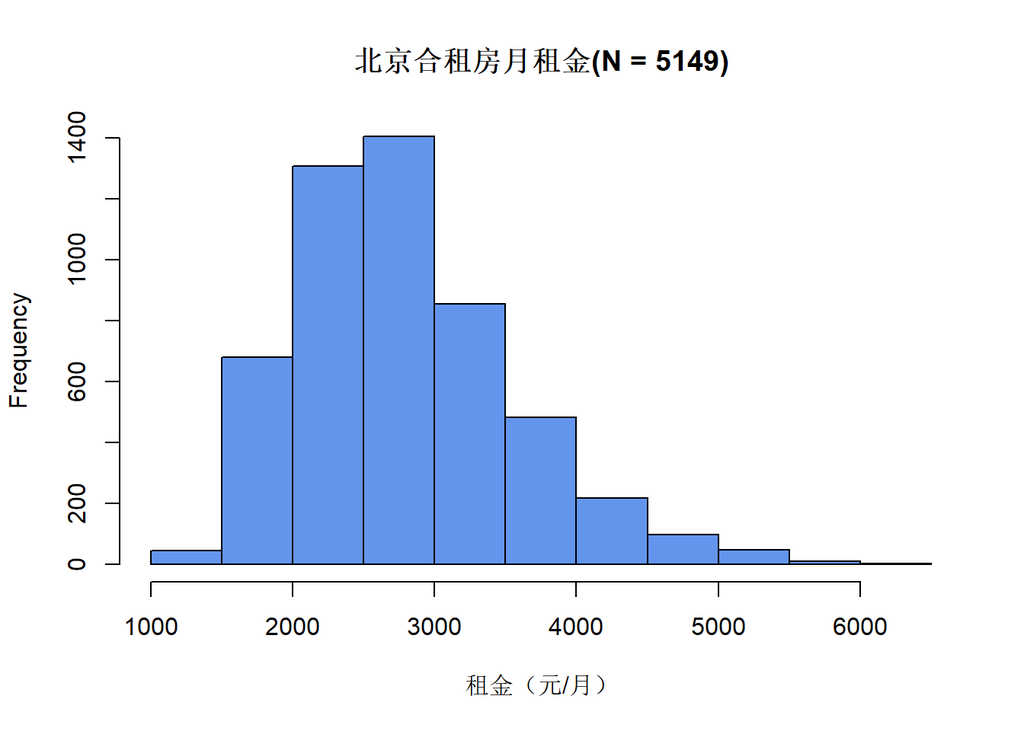

```r
hist(house.data$rent, col = '#6495ED', main = "北京合租房月租金(N = 5149)", xlab = '租金（元/月）')
```

可以看到，月租金分布在2000到3000元之间最多，最低月租金不低于1000元，最高不超过6500元，总体形状呈现右偏。

### $\textbf{·}$ 不同城区租房价格分布

选取平均租金最高的8个城区，绘制降序平均租金柱状图如下：

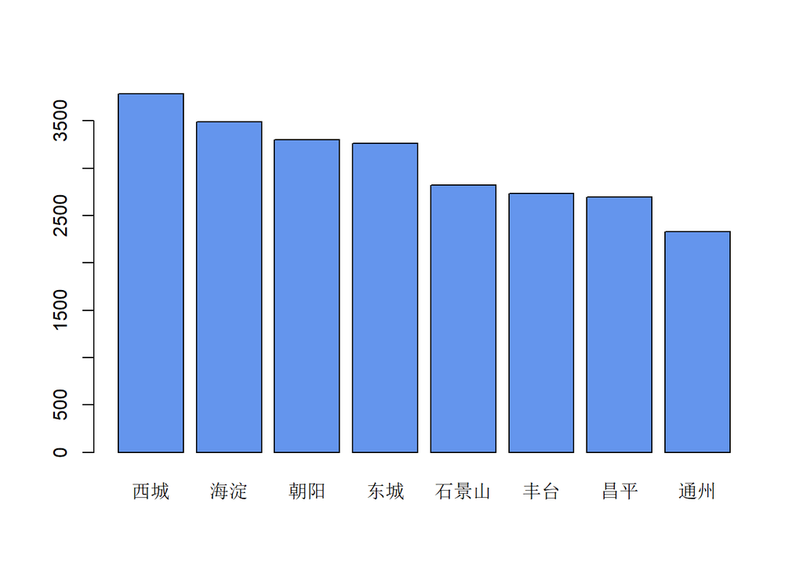

```r
ave.rent <- sort(tapply(house.data$rent, house.data$region, mean), decreasing =T)
barplot(ave.rent[1:8], col = '#6495ED')
```

可以看到，城区之间平均月租金差异明显，在平均月租金前八的城区内，西城有着最高的平均月租金，接近4000元，而通州最低，大约只有2400元左右。

### $\textbf{·}$ 月租金-城区 分组箱线图

绘制月租金(rent)-城区(region)分组箱线图如下：

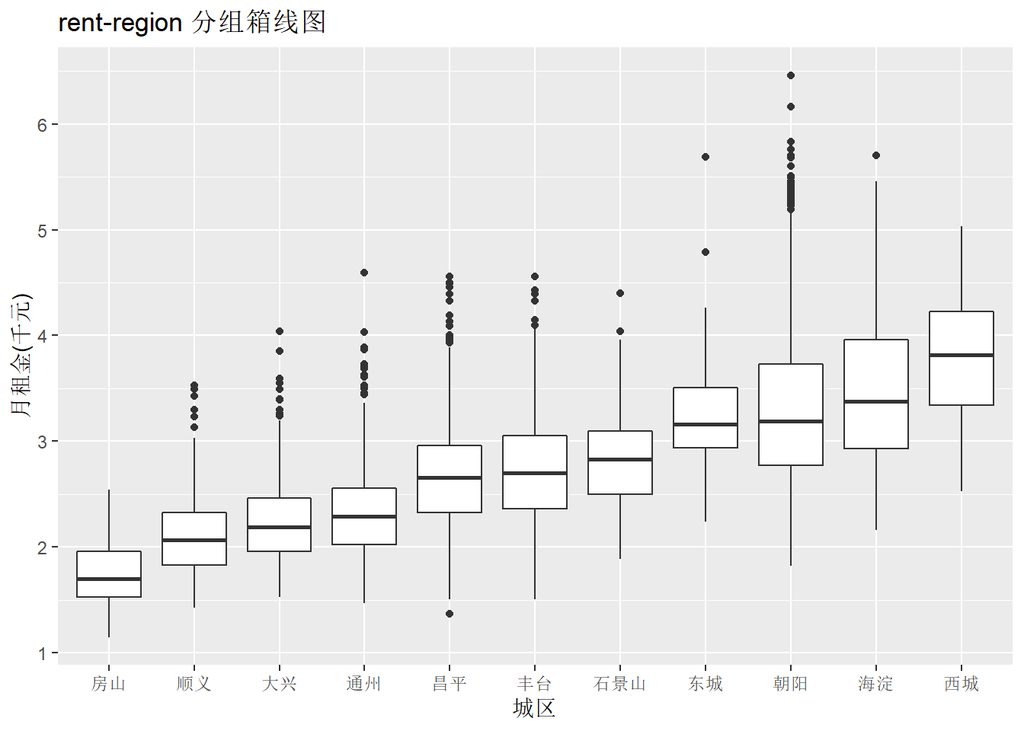

```r
library(ggplot2)
ggplot(house.data, aes(x=reorder(region, rent, median), y=rent/1000)) +
  geom_boxplot() + labs(title="rent-region 分组箱线图",x="城区", y = "月租金(千元)")
```

可以看到，城区之间平均月租金差异明显，部分城区内部也有较大的波动。比如在朝阳、海淀，不同房源间的月租金有较大差异。

### $\textbf{·}$ 线性回归模型

#### $\textbf{·}$ 模型构建

首先为几个定性变量设置对应的哑变量基准组：

*租赁房间变量以“次卧”作为基准组

*所在楼层分组变量以“低楼层”作为基准组

*邻近地铁变量以“否”作为基准组

*城区变量以“石景山”作为基准组

*供暖方式变量以“自采暖”作为基准组

并且将月租金(rent)除以1000，方便观察后续的回归系数。

```r
# 租赁房间变量以“次卧”作为基准组
house.data$room <- factor(house.data$room, levels = c('次卧','主卧'))
# 所在楼层分组变量以“低楼层”作为基准组
house.data$floor_grp <- factor(house.data$floor_grp, levels =c('低楼层','中楼层','高楼层'))
# 邻近地铁变量以“否”作为基准组
house.data$subway <- factor(house.data$subway, levels = c('否','是'))
# 城区变量以“石景山”作为基准组
region.sort <- c( '石景山','西城','海淀','朝阳','东城','丰台','昌平','通州','大兴','顺义','房山')
house.data$region <- factor(house.data$region, levels = region.sort)
# 供暖方式变量以“自采暖”作为基准组
house.data$heating <- factor(house.data$heating, levels = c('自采暖','集中供暖'))
# 将租金除1000，方便观察回归系数
house.data$rent <- house.data$rent/1000
```

以月租金（rent)为因变量，其余为自变量建立线性回归模型，并且查看结果如下：

```r
lm1 = lm(rent~ area + room + bedroom + livingroom + bathroom + heating + floor_grp + subway + region,
         data = house.data)
summary(lm1)
```

```
##
## Call:
## lm(formula = rent ~ area + room + bedroom + livingroom + bathroom +
##     heating + floor_grp + subway + region, data = house.data)
##
## Residuals:
##      Min       1Q   Median       3Q      Max
## -1.61748 -0.27526 -0.02321  0.24840  2.96739
##
## Coefficients:
##                   Estimate Std. Error t value Pr(>|t|)
## (Intercept)      1.593e+00  7.994e-02  19.930  < 2e-16 ***
## area             7.669e-02  1.963e-03  39.065  < 2e-16 ***
## room主卧         8.443e-05  1.657e-02   0.005 0.995935
## bedroom         -9.055e-02  8.740e-03 -10.361  < 2e-16 ***
## livingroom      -1.680e-01  7.184e-02  -2.339 0.019390 *
## bathroom         1.821e-01  4.363e-02   4.174 3.05e-05 ***
## heating集中供暖  1.558e-01  1.713e-02   9.092  < 2e-16 ***
## floor_grp中楼层 -5.560e-02  1.530e-02  -3.634 0.000281 ***
## floor_grp高楼层 -2.499e-02  1.595e-02  -1.566 0.117303
## subway是         2.804e-01  1.774e-02  15.812  < 2e-16 ***
## region西城       9.389e-01  5.433e-02  17.280  < 2e-16 ***
## region海淀       8.789e-01  3.651e-02  24.071  < 2e-16 ***
## region朝阳       6.317e-01  3.170e-02  19.929  < 2e-16 ***
## region东城       5.650e-01  5.506e-02  10.263  < 2e-16 ***
## region丰台       1.176e-01  3.458e-02   3.401 0.000677 ***
## region昌平       5.720e-02  3.407e-02   1.679 0.093245 .
## region通州      -3.730e-01  3.265e-02 -11.424  < 2e-16 ***
## region大兴      -4.220e-01  3.743e-02 -11.275  < 2e-16 ***
## region顺义      -4.510e-01  3.911e-02 -11.530  < 2e-16 ***
## region房山      -8.118e-01  4.502e-02 -18.031  < 2e-16 ***
## ---
## Signif. codes:  0 '***' 0.001 '**' 0.01 '*' 0.05 '.' 0.1 ' ' 1
##
## Residual standard error: 0.4541 on 5129 degrees of freedom
## Multiple R-squared:  0.6466, Adjusted R-squared:  0.6453
## F-statistic: 493.9 on 19 and 5129 DF,  p-value: < 2.2e-16
```

可以看到，各变量的回归系数以及F检验，$R^2$结果如下表所示：

| 变量 | 回归系数 | p值 | 备注 |
| --- | --- | --- | --- |
| 截距项 | 1.593 | <.0001 |  |
| 房间面积 | 0.077 | <.0001 |  |
| 是主卧 | 8.443×$10^{-5}$ | 0.996 |  |
| 卧室数 | -0.091 | <.0001 |  |
| 厅数 | -0.168 | 0.019 |  |
| 卫生间数 | 0.182 | <.0001 |  |
| 是集中供暖 | 0.156 | <.0001 | 基准组：自供暖 |
| 楼层-中楼层 楼层-高楼层 | -0.056 -0.025 | 0.0003 0.117 | 基准组：低楼层 |
| 是地铁房 | 0.280 | <.0001 |  |
| 城区-西城 城区-海淀 城区-朝阳 城区-东城 城区-丰台 城区-昌平 城区-通州 城区-大兴 城区-顺义 城区-房山 | 0.939 0.879 0.632 0.565 0.118 0.057 -0.373 -0.422 -0.451 -0.812 | <.0001 <.0001 <.0001 <.0001 0.0007 0.093 <.0001 <.0001 <.0001 <.0001 | 基准组：石景山 |
| F检验 | p值<.0001 | 调整后的$R^2$ | 0.6453 |

定量变量的相关系数为正，代表其他因素一定，当变量取值越大，月租金越高；相关系数为负，代表其他因素一定，当变量取值越大，月租金越低。比如当房间面积越大，月租金就会越高。而在一组哑变量中，相关系数为正，代表在其他因素一定时，相比于基准组，变量取该值时的月租金更高；相关系数为负，代表在其他因素一定时，相比于基准组，变量取该值时的月租金更低。比如在城区中，相比于石景山，当其他因素都一定时，位于西城的房源有着更高的月租金，而位于通州的房源有着更低的月租金。另外，相关系数的绝对值越大，证明其对租金的影响越大，比如“是否为主卧”，对租金影响就不是很明显。

#### $\textbf{·}$ 模型诊断

对上述回归模型进行模型诊断如下：

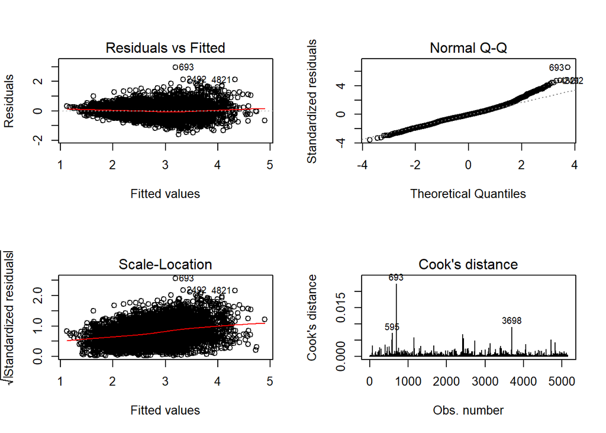

```r
par(mfrow = c(2,2))
plot(lm1, which = c(1:4))
```

### $\textbf{·}$ 变量选择

对上述回归模型，利用BIC准则进行变量选择如下：

```r
slm1 <- step(lm1, direction = 'both', k = log(dim(house.data)[1]))
```

```r
summary(slm1)
```

```
##
## Call:
## lm(formula = rent ~ area + bedroom + bathroom + heating + subway +
##     region, data = house.data)
##
## Residuals:
##      Min       1Q   Median       3Q      Max
## -1.61179 -0.27191 -0.02592  0.24837  2.98050
##
## Coefficients:
##                  Estimate Std. Error t value Pr(>|t|)
## (Intercept)      1.440449   0.059027  24.403  < 2e-16 ***
## area             0.076527   0.001533  49.930  < 2e-16 ***
## bedroom         -0.091457   0.008547 -10.701  < 2e-16 ***
## bathroom         0.141751   0.040550   3.496 0.000477 ***
## heating集中供暖  0.154970   0.017150   9.036  < 2e-16 ***
## subway是         0.281206   0.017743  15.849  < 2e-16 ***
## region西城       0.935072   0.054387  17.193  < 2e-16 ***
## region海淀       0.880960   0.036546  24.106  < 2e-16 ***
## region朝阳       0.634860   0.031729  20.009  < 2e-16 ***
## region东城       0.565767   0.055124  10.264  < 2e-16 ***
## region丰台       0.119461   0.034606   3.452 0.000561 ***
## region昌平       0.058700   0.034104   1.721 0.085276 .
## region通州      -0.372159   0.032685 -11.386  < 2e-16 ***
## region大兴      -0.418866   0.037422 -11.193  < 2e-16 ***
## region顺义      -0.456412   0.039038 -11.691  < 2e-16 ***
## region房山      -0.808478   0.045011 -17.962  < 2e-16 ***
## ---
## Signif. codes:  0 '***' 0.001 '**' 0.01 '*' 0.05 '.' 0.1 ' ' 1
##
## Residual standard error: 0.4547 on 5133 degrees of freedom
## Multiple R-squared:  0.6453, Adjusted R-squared:  0.6443
## F-statistic: 622.7 on 15 and 5133 DF,  p-value: < 2.2e-16
```

可以发现，经过BIC准则的选择，原来的9个变量变为6个，分别是：租赁房间面积(area)、卧室数(bedroom)、卫生间数(bathroom)、供暖方式(heating)、是否邻近地铁(subway)、所在城区(region)；以下3个变量被去除：租赁房间类型(room)、厅数(livingroom)、所在楼层(floor_grp)。具体结果由下表展示：

| 变量 | 回归系数 | p值 | 备注 |
| --- | --- | --- | --- |
| 截距项 | 1.440 | <.0001 |  |
| 房间面积 | 0.077 | <.0001 |  |
| 卧室数 | -0.091 | <.0001 |  |
| 卫生间数 | 0.142 | 0.0005 |  |
| 是集中供暖 | 0.155 | <.0001 | 基准组：自供暖 |
| 是地铁房 | 0.281 | <.0001 |  |
| 城区-西城 城区-海淀 城区-朝阳 城区-东城 城区-丰台 城区-昌平 城区-通州 城区-大兴 城区-顺义 城区-房山 | 0.935 0.881 0.635 0.566 0.119 0.059 -0.372 -0.419 -0.456 -0.808 | <.0001 <.0001 <.0001 <.0001 0.0006 0.085 <.0001 <.0001 <.0001 <.0001 | 基准组：石景山 |
| F检验 | p值<.0001 | 调整后的$R^2$ | 0.6443 |

### $\textbf{·}$ 模型验证

首先，编写一个用于交叉验证的函数*pred.cv*如下：

```r
pred.cv <- function(dat, k){
  ind <- sample(1:k, nrow(dat), replace = T)
  pred_cv <- rep(0, nrow(dat))
  for (i in 1:k){
    ii <- which(ind == i)
    obj <- lm(rent~ area + bedroom + bathroom + heating + subway + region,
                     data = dat[-ii,])
    pred_cv[ii] <- predict(obj, dat[ii,])
  }
  rmse <- sqrt(mean((pred_cv - dat$rent)^2))
  return (list(pred_cv = pred_cv, rmse = rmse))
}
```

使用该函数，对上述经过BIC准则修正过的模型进行五折交叉验证,重复50次，运行如下：

```r
set.seed(1234)
rmses <- rep(0, 50)
for (i in 1:50) {
  cat(i, '\r')
  pred_cv <- pred.cv(dat = house.data, k = 5)
  rmses[i] <- pred_cv$rmse
}
```

计算这50次的五折交叉验证的平均mse如下：

```r
mean(rmses)
```

```
## [1] 0.4554944
```

可以看到，平均mse不大，只有0.455（在rent以“千元”为单位时），说明了模型的合理性。

### $\textbf{·}$ 模型改进

在前述模型诊断中，发现模型存在一定程度上的非线性以及异方差现象，现使用对数回归模型，改进原模型。

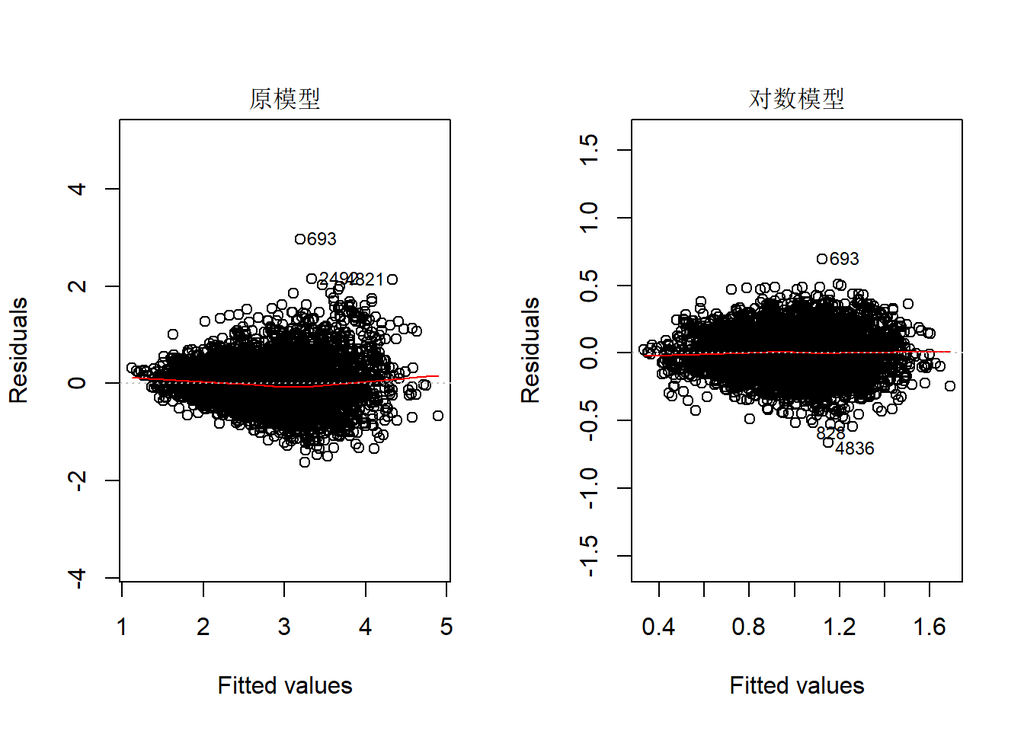

```r
lm2 = lm(log(rent)~ area + room + bedroom + livingroom + bathroom + heating + floor_grp + subway + region,
         data = house.data)
par(mfrow = c(1,2))
plot(lm1, which = c(1), ylab('原模型'), asp=0.6)
plot(lm2, which = c(1), ylab('对数模型'), asp=0.6)
```

可以看到，使用对数线性回归模型，异方差问题和非线性问题均得到一定程度上的改善。

对该对数模型使用BIC准则进行选择：

```r
slm2 <- step(lm2, direction = 'both', k = log(dim(house.data)[1]))
```

```r
summary(slm2)
```

[output not shown]

使用对数模型时，对y的预测应该为$e^{x^T\beta + \frac{\sigma^2}{2}}$(在上次作业时有过证明)。而因为$\sigma$未知，故我们用数据拟合出来的$\widehat{\sigma}$来代替$\sigma$。使用以下新的自定义五折交叉验证函数对其进行验证：

```r
pred.cv1 <- function(dat, k){
  ind <- sample(1:k, nrow(dat), replace = T)
  pred_cv <- rep(0, nrow(dat))
  for (i in 1:k){
    ii <- which(ind == i)
    obj <- lm(log(rent)~ area + bedroom + bathroom + heating + subway + region, data = dat[-ii,])
    sigma <- summary(obj)$sigma
    pred_cv[ii] <- exp(predict(obj, dat[ii,]) + 0.5*sigma ^2)
  }
  rmse <- sqrt(mean((pred_cv - dat$rent)^2))
  return (list(pred_cv = pred_cv, rmse = rmse))
}

set.seed(1234)
rmses <- rep(0, 50)
for (i in 1:50) {
  cat(i, '\r')
  pred_cv1 <- pred.cv1(dat = house.data, k = 5)
  rmses[i] <- pred_cv1$rmse
}
```

```r
mean(rmses)
```

```
## [1] 0.4518
```

可以看到，使用对数线性模型，模型性能得到一定程度上的优化，rmse降低了约0.81%。

(注：因为在五折交叉验证时，我计算的是“预测出来的rent值”来与“真实的rent值”进行残差评估，这一点与普通的线性模型是一致的，故我比较了两者的平均rmse。)